# NDVTransmissionTrial

Egil A.J. Fischer

04-03-2020

# Introduction

- Background trial
- Background transmission models

## Objectives

- Estimation of infectious period for vaccinated and unvaccinated
- Estimation of transmission parameter beta for vaccinated and unvaccinated
- Estimation of R0 for vaccinated and unvaccinated

# Material and methods

## Estimation of infectious period

## Estimation of the transmission parameter $\beta$

## Estimation of the basic reproduction number $\textit{R}_0$

# Results

## Load and organize data

The data sets consist of two separate data files in ‘xlsx’ format. These files need to be combined to form one data set

```r
data.dir <- "C:/Surfdrive/Projecten/CEVA/"
#read the data of the vaccination group
cevadata1A <- read.xlsx(paste0(data.dir,
"P062VectormuneNDtransmissionstudysheddingdata_setA_readible.xlsx"),
                      sheet = "Group1A")
cevadata2A <- read.xlsx(paste0(data.dir, "P062VectormuneNDtransmissionstudysheddingdata_setA_readible.xlsx"),
                        sheet = "Group2A")
cevadata1B <- read.xlsx(paste0(data.dir,
"P062VectormuneNDtransmissionstudysheddingdata_setB_readible.xlsx"),
                      sheet = "Group1B")
cevadata2B <- read.xlsx(paste0(data.dir, "P062VectormuneNDtransmissionstudysheddingdata_setB_readible.xlsx"),
                        sheet = "Group2B")

cevadata <- rbind(cevadata1A,cevadata1B,cevadata2A,cevadata2B)
```

with variables

```r
names(cevadata)
```

```
##  [1] "Group"      "Vaccinated" "Challenge"  "bird.id"    "Sample"
##  [6] "1.dpch"     "2.dpch"     "3.dpch"     "4.dpch"     "5.dpch"
## [11] "6.dpch"     "7.dpch"     "8.dpch"     "9.dpch"     "10.dpch"
## [16] "11.dpch"    "12.dpch"    "13.dpch"    "14.dpch"    "NP.ELISA"
```

Now rename to standard naming convention:

```r
#rename to standard
cevadata$ci <- sapply(cevadata$Challenge, FUN = function(x){ifelse(grepl("contact", x),"contact","seeder")})
```

Define a function `reform.data` to rearrange the data for analyses. The function takes the data and use the names of the sampledays, determine positivity based on one or all positive samples, and define the cutt-off value for positivity.

## Descriptive data

### Epidemic curves

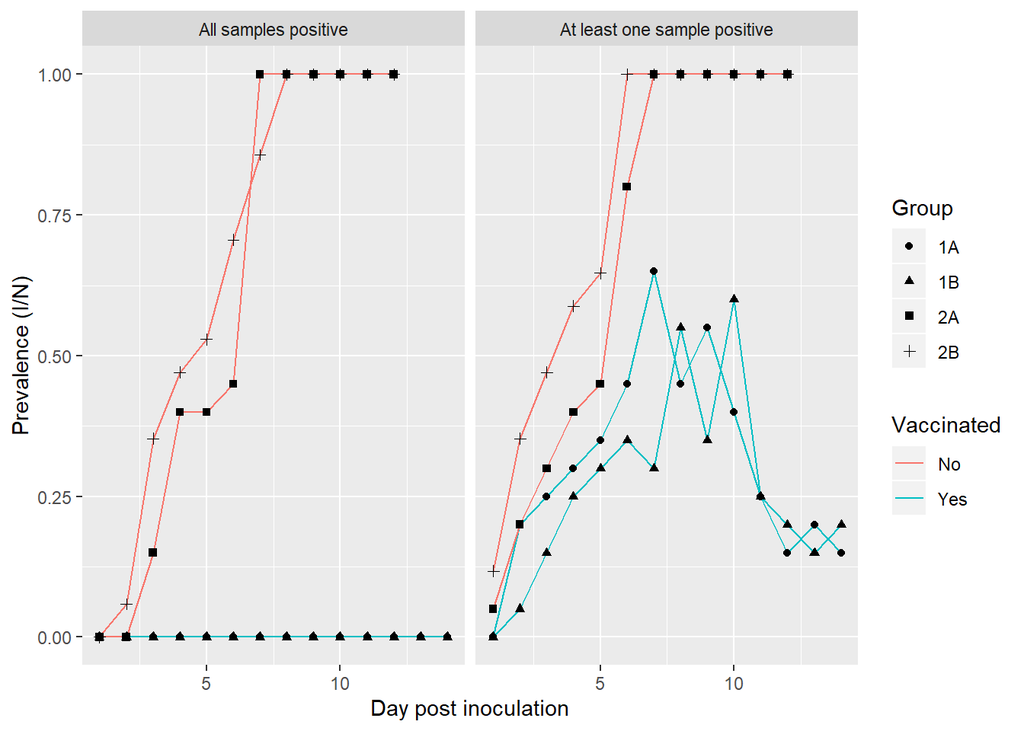

Infection curves

```r
epicurveplot
```

The separate swabs represent the following epidemic curves:

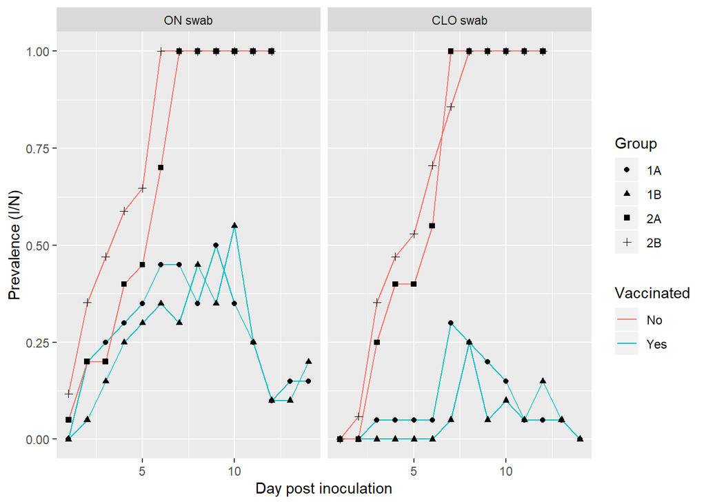

Infection curves

```r
epicurveplot
```

On first sight the curves are similar for the unvaccinated groups, but the CLO swab are less likely and later positive than the ON swab in the vaccinated groups.

# Transmission parameters

## One positive sample

### Infectious period

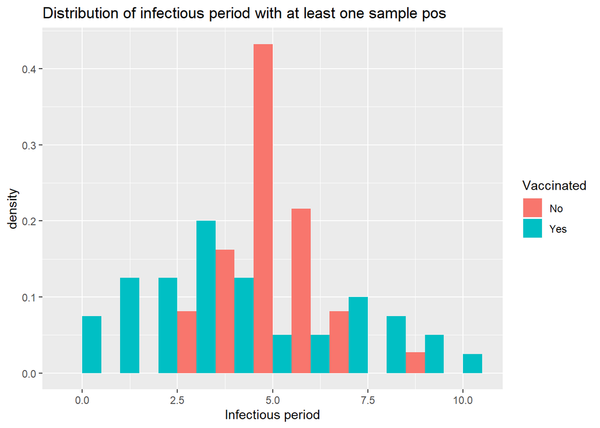

```r
#visualize
ggplot(data = out.indiv) +
  geom_histogram(aes(x = infper, y = ..density.., fill = Vaccinated), position = "dodge",binwidth = 1)+
  ggtitle("Distribution of infectious period with at least one sample pos")+
  xlab("Infectious period")
```

Descriptive statistics for the infectious period.

```r
table.infper
```

```
##          Group     Mean       SD
## 1      Overall 4.571429 2.232703
## 2 Unvaccinated 5.162162 1.213661
## 3   Vaccinated 4.025000 2.778004
```

From the table it already seems that the variances are not equal. Therefor we first test for equality of variance and than do the appropriate test to compare means.

```r
#test for equal variances
fligner.test(out.indiv$infper, out.indiv$Vaccinated) #conclude unequal variances
```

```
##
##  Fligner-Killeen test of homogeneity of variances
##
## data:  out.indiv$infper and out.indiv$Vaccinated
## Fligner-Killeen:med chi-squared = 13.666, df = 1, p-value = 0.0002184
```

```r
#Compare the mean infectious period
t.test(out.indiv$infper~out.indiv$Vaccinated,var.equal = FALSE) #conclude no difference in mean
```

```
##
##  Welch Two Sample t-test
##
## data:  out.indiv$infper by out.indiv$Vaccinated
## t = 2.3571, df = 54.253, p-value = 0.02205
## alternative hypothesis: true difference in means is not equal to 0
## 95 percent confidence interval:
##  0.170043 2.104281
## sample estimates:
##  mean in group No mean in group Yes
##          5.162162          4.025000
```

```r
#Compare the sd infectious period
var.test(out.indiv$infper~out.indiv$Vaccinated)
```

```
##
##  F test to compare two variances
##
## data:  out.indiv$infper by out.indiv$Vaccinated
## F = 0.19087, num df = 36, denom df = 39, p-value = 2.188e-06
## alternative hypothesis: true ratio of variances is not equal to 1
## 95 percent confidence interval:
##  0.1000171 0.3673606
## sample estimates:
## ratio of variances
##          0.1908662
```

The vaccinated group has a lower mean infectious period, but a larger variance.

### Transmission parameters $\beta$ and $R_0$

```r
#test glm
fit.full <- glm(cbind(out.nona$C, out.nona$S-out.nona$C) ~ out.nona$Vaccinated +out.nona$Group, offset = log(out.nona$I/out.nona$N), family = binomial(link = "cloglog"), data = out.nona, na.action = na.omit)
drop1(fit.full)
```

```
## Single term deletions
##
## Model:
## cbind(out.nona$C, out.nona$S - out.nona$C) ~ out.nona$Vaccinated +
##     out.nona$Group
##                     Df Deviance    AIC
## <none>                   81.620 168.00
## out.nona$Vaccinated  0   81.620 168.00
## out.nona$Group       2   85.748 168.13
```

In backward selection Group falls out, but vaccination stays in.

```r
fit.empty <- glm(cbind(out.nona$C, out.nona$S-out.nona$C) ~1,offset = log(out.nona$I/out.nona$N), family = binomial(link = "cloglog"), data = out.nona, na.action = na.omit)
add1(fit.empty, ~. + out.nona$Vaccinated + out.nona$Group)
```

```
## Single term additions
##
## Model:
## cbind(out.nona$C, out.nona$S - out.nona$C) ~ 1
##                     Df Deviance    AIC
## <none>                   91.283 171.66
## out.nona$Vaccinated  1   85.748 168.13
## out.nona$Group       3   81.620 168.00
```

```r
fit.vac <- glm(cbind(out.nona$C, out.nona$S-out.nona$C) ~out.nona$Vaccinated,offset = log(out.nona$I/out.nona$N), family = binomial(link = "cloglog"), data = out.nona, na.action = na.omit)
add1(fit.vac, scope = ~.+na.omit(out.nona$Group))
```

```
## Single term additions
##
## Model:
## cbind(out.nona$C, out.nona$S - out.nona$C) ~ out.nona$Vaccinated
##                         Df Deviance    AIC
## <none>                       85.748 168.13
## na.omit(out.nona$Group)  2   81.620 168.00
```

```r
fit.group <- glm(cbind(out.nona$C, out.nona$S-out.nona$C) ~out.nona$Group,offset = log(out.nona$I/out.nona$N), family = binomial(link = "cloglog"), data = out.nona, na.action = na.omit)
add1(fit.group, ~.+out.nona$Vaccinated)
```

```
## Single term additions
##
## Model:
## cbind(out.nona$C, out.nona$S - out.nona$C) ~ out.nona$Group
##                     Df Deviance AIC
## <none>                    81.62 168
## out.nona$Vaccinated  0    81.62 168
```

In forward selection both groups and vaccination are added as single terms to improve the empty model, but the addition of Group in the vaccine model or vaccination in the group model shows that Group should not be included in the model.

```r
summary(fit.vac)
```

```
##
## Call:
## glm(formula = cbind(out.nona$C, out.nona$S - out.nona$C) ~ out.nona$Vaccinated,
##     family = binomial(link = "cloglog"), data = out.nona, na.action = na.omit,
##     offset = log(out.nona$I/out.nona$N))
##
## Deviance Residuals:
##     Min       1Q   Median       3Q      Max
## -2.5373  -1.1985  -0.3804   1.0257   3.2453
##
## Coefficients:
##                        Estimate Std. Error z value Pr(>|z|)
## (Intercept)              0.1185     0.1708   0.694   0.4879
## out.nona$VaccinatedYes  -0.5181     0.2146  -2.414   0.0158 *
## ---
## Signif. codes:  0 '***' 0.001 '**' 0.01 '*' 0.05 '.' 0.1 ' ' 1
##
## (Dispersion parameter for binomial family taken to be 1)
##
##     Null deviance: 91.283  on 36  degrees of freedom
## Residual deviance: 85.748  on 35  degrees of freedom
## AIC: 168.13
##
## Number of Fisher Scoring iterations: 5
```

Vaccination lowers the infeection parameter $\beta$.

```r
beta.table
```

```
##        beta      2.5%     97.5
## 1 1.1257870 0.7899902 1.547889
## 2 0.6705952 0.4431067 1.030285
```

### Basic reproduction number $R_0$

```r
mean.R0[, c(1,2,3,4)]
```

```
##             Vaccinated      beta    llbeta    ulbeta
## (Intercept)         No 1.1257870 0.8893607 1.7425939
##                    Yes 0.6705952 0.2639445 0.6137075
```

```r
mean.R0[, c(1,5,6,7)]
```

```
##             Vaccinated   infper llinfper ulinfper
## (Intercept)         No 5.162162 4.771101 5.553223
##                    Yes 4.025000 3.164103 4.885897
```

```r
mean.R0[, c(1,11,12,13)]
```

```
##             Vaccinated        R      llR      ulR
## (Intercept)         No 5.657064 3.749388 8.535361
##                    Yes 2.046461 1.033402 4.052636
```

## Both positive samples

### Infectious period

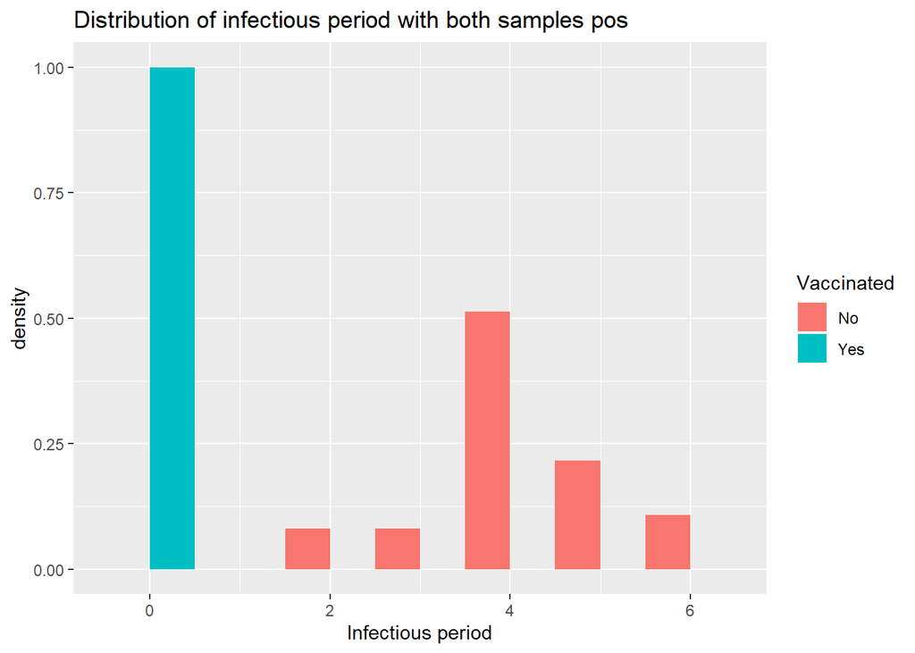

```r
#visualize
ggplot(data = out.indiv) +
  geom_histogram(aes(x = infper, y = ..density.., fill = Vaccinated), position = "dodge",binwidth = 1)+
  ggtitle("Distribution of infectious period with both samples pos")+
  xlab("Infectious period")
```

Descriptive statistics for the infectious period.

```r
table.infper
```

```
##          Group     Mean       SD
## 1      Overall 2.012987 2.221270
## 2 Unvaccinated 4.189189 1.023009
## 3   Vaccinated 0.000000 0.000000
```

Using the assumption that both swabs need a positive result, the vaccinated group is never infectious.

## ON sample positive

### Infectious period

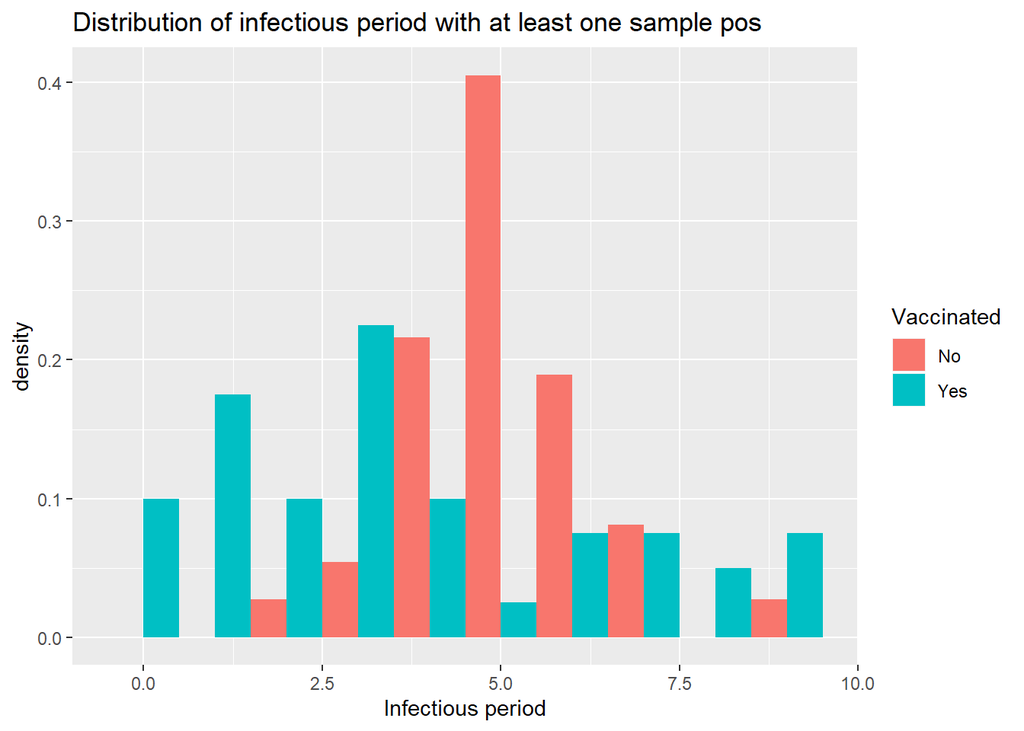

```r
#visualize
ggplot(data = out.indiv) +
  geom_histogram(aes(x = infper, y = ..density.., fill = Vaccinated), position = "dodge",binwidth = 1)+
  ggtitle("Distribution of infectious period with at least one sample pos")+
  xlab("Infectious period")
```

Descriptive statistics for the infectious period.

```r
table.infper
```

```
##          Group     Mean       SD
## 1      Overall 4.311688 2.272604
## 2 Unvaccinated 5.054054 1.289831
## 3   Vaccinated 3.625000 2.742706
```

From the table it already seems that the variances are not equal. Therefor we first test for equality of variance and than do the appropriate test to compare means.

```r
#test for equal variances
fligner.test(out.indiv$infper, out.indiv$Vaccinated) #conclude unequal variances
```

```
##
##  Fligner-Killeen test of homogeneity of variances
##
## data:  out.indiv$infper and out.indiv$Vaccinated
## Fligner-Killeen:med chi-squared = 12.14, df = 1, p-value = 0.0004936
```

```r
#Compare the mean infectious period
t.test(out.indiv$infper~out.indiv$Vaccinated,var.equal = FALSE) #conclude no difference in mean
```

```
##
##  Welch Two Sample t-test
##
## data:  out.indiv$infper by out.indiv$Vaccinated
## t = 2.9604, df = 56.387, p-value = 0.004488
## alternative hypothesis: true difference in means is not equal to 0
## 95 percent confidence interval:
##  0.4621832 2.3959249
## sample estimates:
##  mean in group No mean in group Yes
##          5.054054          3.625000
```

```r
#Compare the sd infectious period
var.test(out.indiv$infper~out.indiv$Vaccinated)
```

```
##
##  F test to compare two variances
##
## data:  out.indiv$infper by out.indiv$Vaccinated
## F = 0.22116, num df = 36, denom df = 39, p-value = 1.358e-05
## alternative hypothesis: true ratio of variances is not equal to 1
## 95 percent confidence interval:
##  0.1158917 0.4256676
## sample estimates:
## ratio of variances
##          0.2211602
```

The vaccinated group has a lower mean infectious period, but a larger variance.